# Bayesian analysis of spatio-temporal patterns of mortality in Italy using the Lee-Carter model

Sara Martino

NTNU, Trondheim

Francesca Fiori

University of Strathclyde, Glasgow

Andrea Riebler

NTNU, Trondheim

Sep 16, 2025

# Introduction

## Italy as a case-study of mortality trends

1. Some of the lowest mortality levels in Europe: life expectancy of 83.4 in 2023.
2. Marked geographical differences, reflecting inequalities in wealth, educational level and employment opportunities.
3. Slowdown of mortality improvements since 2010.

Well documented existence of a gendered geography of mortality in the second half of the 20th century – but surprisingly little attention to the geography of mortality in the 21st century

## Research questions

The study contributes to understandings of geographical inequalities in mortality in the 21st century by asking:

1. How has gender- and age-specific mortality evolved over the last two decades?
2. How did mortality by age and gender vary at the provincial level?
3. And have geographical inequalities widened during the slowdown of survival improvement of the 2010s?

## Research questions

The study contributes to understandings of geographical inequalities in mortality in the 21st century by asking:

1. How has gender- and age-specific mortality evolved over the last two decades?
2. How did mortality by age and gender vary at the provincial level?
3. And have geographical inequalities widened during the slowdown of survival improvement of the 2010s?

**Model 1**

**Model 2**

# Data

## Data

ISTAT series of deaths and population counts:

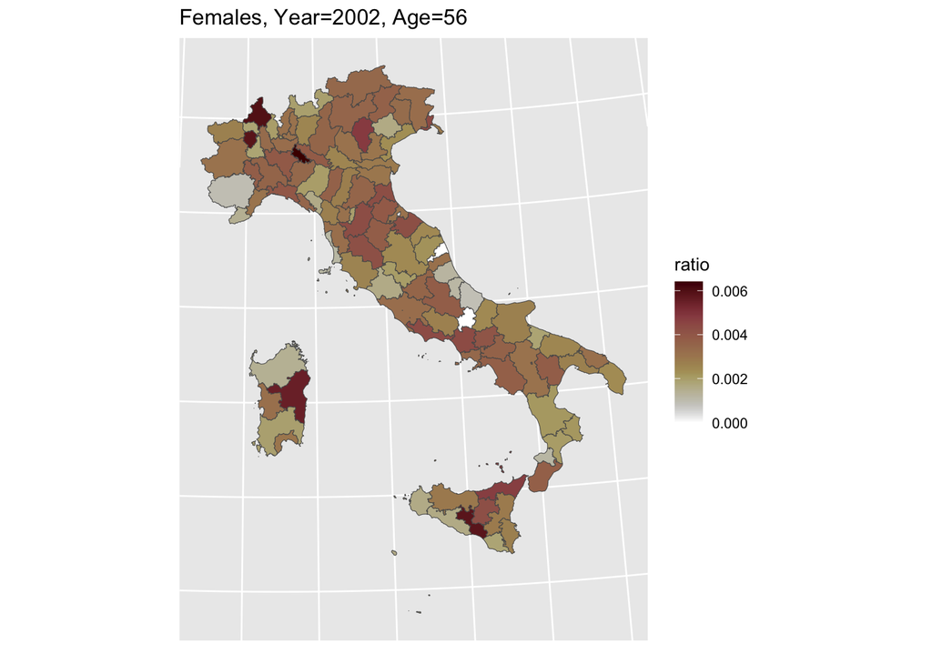

Good quality registers data – but subject to random variability given the varying (and small) size of the territorial units they refer to.

# Model

## The Lee Carter Model (with a spatial extension)

We assume the counts to be Poisson distributed
$$Y_{xts}|\lambda_{xts}\sim\text{Poisson}(E_{xts}e^{\lambda_{xts}})$$
with
$$\lambda_{xts} = \alpha_x + \beta_x\kappa_t + \omega_{sg_x}+ \epsilon_{xts}$$

## The Lee Carter Model (with a spatial extension)

We assume the counts to be Poisson distributed
$$Y_{xts}|\lambda_{xts}\sim\text{Poisson}(E_{xts}e^{\lambda_{xts}})$$
with
$$\lambda_{xts} = \underbrace{\alpha_x + \beta_x\kappa_t}_{1} + \omega_{sg_x} + \epsilon_{xts}$$
1. Traditional Lee-Carter model

- $\alpha_x$: age profile (Gaussian iid model)
- $\kappa_t$: time effect (RW2 model)
- $\beta_x$: age-specific multiplication factor (Gaussian iid model)

## The Lee Carter Model (with a spatial extension)

We assume the counts to be Poisson distributed
$$Y_{xts}|\lambda_{xts}\sim\text{Poisson}(E_{xts}e^{\lambda_{xts}})$$
with
$$\lambda_{xts} = \underbrace{{\alpha_x + \beta_x\kappa_t}}_{1} + \underbrace{\omega_{sg_x}}_{2} + \epsilon_{xts}$$
1. Traditional Lee-Carter model

2. Spatial effect: allowed to vary over 10 different age classes (ICAR model for each age class)

## The Lee Carter Model (with a spatial extension)

We assume the counts to be Poisson distributed
$$Y_{xts}|\lambda_{xts}\sim\text{Poisson}(E_{xts}e^{\lambda_{xts}})$$
with
$$\lambda_{xts} = \underbrace{\alpha_x + \beta_x\kappa_t}_{1} + \underbrace{\omega_{sg_x}}_{2} + \underbrace{\epsilon_{xts}}_{3}$$

1. Traditional Lee-Carter model
2. Spatial effect: allowed to vary for 10 different age classes
3. iid effect to account for overdispersion

## The Lee-Carter model - Priors and constraints

- We model males and females separately

## The Lee-Carter model - Priors and constraints

- We model males and females separately
- The model is over-parametrised and need some constraint to be identifiable
  - $\sum_x\alpha_x = 0$
  - $\sum_x\beta_x = 1$
  - $\sum_s\omega_{sg_x} = 0$ for every age class $g_x$

## The Lee-Carter model - Priors and constraints

- We model males and females separately
- The model is over-parametrised and need some constraint to be identifiable
- Prior for model parameters
  - We use PC-priors for all precision parameters.

## A second model…

$$Y_{xts}|\lambda_{xts}\sim\text{Poisson}(E_{xts}e^{\lambda_{xts}})$$
with
$$\lambda_{xts} = \alpha_x + \beta_x\kappa_t + \omega_{s g_x p_t}+ \epsilon_{xts}$$
with

$$p_t = \left\{
\begin{aligned}
1 & \text{ for years 2002-2010}\\
2 & \text{ for years 2011-2019}\\
\end{aligned}
\right.$$

# Inference

## Inference using `inlabru`

$$\begin{aligned}
\lambda_{xts} & = \alpha_x + \beta_x\kappa_t + \omega_{sg_x} + \epsilon_{xts} = \tilde{\eta}(\mathbf{u})\\
\mathbf{u} & = \{\alpha, \beta, \kappa, \omega,\epsilon\}\sim\mathcal{N}(\mathbf{0},\mathbf{Q}^{-1})
\end{aligned}$$

- We use the iterative procedure implemented in the `inlabru` package to solve the inferential problem
- In practice one linearizes the problem using a first order Taylor expansion and iteratively applies INLA until convergence.

# Results

## Mortality over time by age and gender

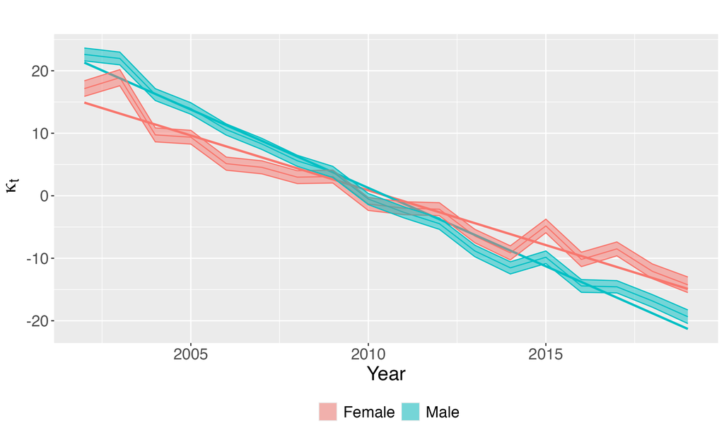

Time effect

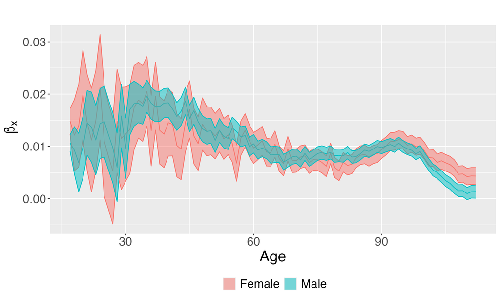

Age-specific multiplication factor

## Geographical variation in mortality by age and gender over the whole time period

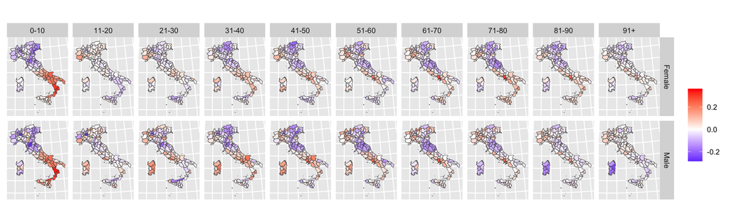

## Widening geographical inequalities over time - Females

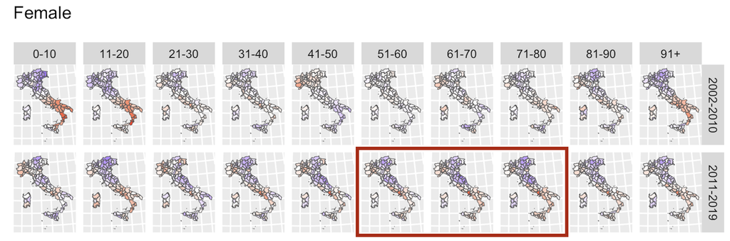

## Widening geographical inequalities over time - Males

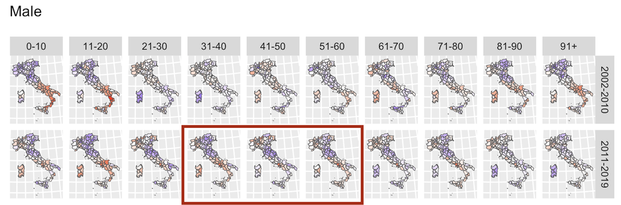

## Concluding remarks

- Fine geographical analyses are crucial to understand current trends, and anticipate future ones.
- We demonstrated the value of a Bayesian framework, and the advantage of using inlabru, for estimating age and gender specific mortality at the provincial level.
- Results indicate a widening of geographical inequalities in the most recent decade, particularly for:
  - Women aged between 50 and 80
  - Men aged between 30 and 60

# Future Work

## Future work

- Decomposing mortality by (large) causes of death.
- Investigating socio-economic inequalities through linkages to individual characteristics from census.
- Investigating contextual underlying factors that may be holding back progress for some.
- Forecasting future trends for small areas and/or population groups